# Tarea2. Parte 3

David Bello Jiménez

2022-07-14

# Elaboración de modelos de distribución y de hábitat de una especie vegetal

## ESPECIE PROPIA - Ceratonia siliqua

### Paso 3. Análisis de multicolinealidad y selección de variables

Cargamos paquetes y librerias basicos en el espacio de trabajo

```r
library(raster)
library(rgdal)
library(spatstat)
library(spatialEco)
library(usdm) # Analisis de incertidumbre para modelos de distribucion de especies
```

```r
library(ggplot2) # Powerful graphics language for creating elegant and complex plots
```

Establecemos ruta para los rasters, los resultados y las variables seleccionadas.

```r
path2layers<-"./2_WorldClim_R/bio"

path2work1<-"./3_test_multicolinealidad/resultados/"

path2work2<-"./3_test_multicolinealidad/resultados/variables_seleccionadas/"
```

Cargamos las variables en un stack, vemos sus estadísticos descriptivos con summary() y exploramos la estructura de las variables:

```r
VAR_PI <- stack(list.files(path=path2layers,pattern='asc',full.names=TRUE))
names(VAR_PI)
```

```
##  [1] "alt"   "bio1"  "bio10" "bio11" "bio12" "bio13" "bio14" "bio15" "bio16"
## [10] "bio17" "bio18" "bio19" "bio2"  "bio3"  "bio4"  "bio5"  "bio6"  "bio7"
## [19] "bio8"  "bio9"
```

```r
summary(VAR_PI)
```

```
##                 alt bio1 bio10 bio11 bio12 bio13 bio14 bio15 bio16 bio17 bio18
## Min.      -1.741419    7    79   -53   193    24     0    11    64     7     9
## 1st Qu.  244.554947  118   191    46   464    61     4    28   161    32    35
## Median   554.825317  138   215    66   577    78    12    39   213    62    69
## 3rd Qu.  834.126526  159   237    90   779   103    28    53   283   110   122
## Max.    2552.122314  192   280   135  1708   263    97    85   697   321   321
## NA's    5817.000000 6029  6029  6029  6029  6029  6029  6029  6029  6029  6029
##         bio19 bio2 bio3 bio4 bio5 bio6 bio7 bio8 bio9
## Min.       47   54   26 2680  131  -90  127   -4  -24
## 1st Qu.   124   91   36 5217  261    0  240   83  183
## Median    186  102   38 5780  289   18  268  104  211
## 3rd Qu.   258  112   39 6286  315   46  293  125  235
## Max.      697  129   50 7296  363   91  335  206  279
## NA's     6029 6029 6029 6029 6029 6029 6029 6029 6029
```

```r
print(VAR_PI)
```

```
## class      : RasterStack
## dimensions : 105, 166, 17430, 20  (nrow, ncol, ncell, nlayers)
## resolution : 0.08333333, 0.08333333  (x, y)
## extent     : -9.416667, 4.416667, 35.16667, 43.91667  (xmin, xmax, ymin, ymax)
## crs        : NA
## names      : alt, bio1, bio10, bio11, bio12, bio13, bio14, bio15, bio16, bio17, bio18, bio19, bio2, bio3, bio4, ...
```

Asignamos sistema de coordenadas y visualizamos el resultado:

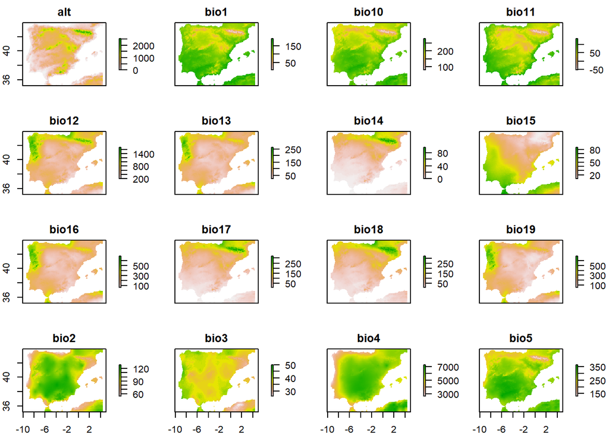

```r
crs(VAR_PI) <- "+proj=longlat +ellps=WGS84 +datum=WGS84 +no_defs"

plot(VAR_PI)
```

Eliminamos del stack los índices que suelen dar problemas bio_3, bio_14, bio_15 (Varela_et_al_2015_PLoSONE):

```r
names(VAR_PI)
```

```
##  [1] "alt"   "bio1"  "bio10" "bio11" "bio12" "bio13" "bio14" "bio15" "bio16"
## [10] "bio17" "bio18" "bio19" "bio2"  "bio3"  "bio4"  "bio5"  "bio6"  "bio7"
## [19] "bio8"  "bio9"
```

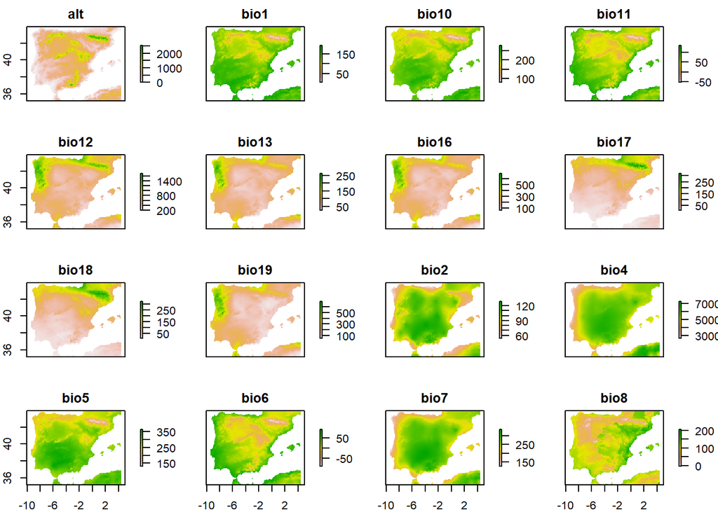

```r
VAR_PI_DEF <- dropLayer(VAR_PI, c(7, 8, 14))
plot(VAR_PI_DEF)
```

Calculamos el Factor de Inflación de la Varianza (VIF) basándonos en las funciones vifcor y vifstep:

-vifcor busca un par de variables que tengan la maxima correlacion lineal (mayor que th) y excluye una de ellas que tenga mayor VIF. El procedimiento se repite hasta que no quede ninguna variable con alto coeficiente de correlacion (mayor que el umbral) con otras variables. -vifstep calcula el VIF para todas las variables, excluye una con el VIF mas alto (mayor que el umbral), repite el procedimiento hasta que no quede ninguna variable con VIF mayor que th.

Una vez hecho, usamos la variable que recoge el resultado para excluir las variables seleccionadas y observamos el resultado.

```r
v1 <- vifcor(VAR_PI_DEF, th=0.8)
v1
```

```
## 9 variables from the 17 input variables have collinearity problem:
##
## bio16 bio18 bio6 bio19 bio11 bio7 bio12 bio10 bio5
##
## After excluding the collinear variables, the linear correlation coefficients ranges between:
## min correlation ( bio4 ~ bio1 ):  -0.01577347
## max correlation ( bio1 ~ alt ):  -0.7961471
##
## ---------- VIFs of the remained variables --------
##   Variables       VIF
## 1       alt  7.652698
## 2      bio1 15.521279
## 3     bio13  2.508518
## 4     bio17  5.480313
## 5      bio2  2.320858
## 6      bio4  3.209540
## 7      bio8  2.179001
## 8      bio9  2.631979
```

```r
v2 <- vifstep(VAR_PI_DEF, th=3)
v2
```

```
## 10 variables from the 17 input variables have collinearity problem:
##
## bio5 bio10 bio11 bio16 bio7 bio12 bio6 bio18 bio19 bio1
##
## After excluding the collinear variables, the linear correlation coefficients ranges between:
## min correlation ( bio9 ~ bio8 ):  -0.01800122
## max correlation ( bio4 ~ bio2 ):  0.6822772
##
## ---------- VIFs of the remained variables --------
##   Variables      VIF
## 1       alt 2.648378
## 2     bio13 2.416182
## 3     bio17 2.131135
## 4      bio2 2.087545
## 5      bio4 2.800084
## 6      bio8 2.020829
## 7      bio9 2.261892
```

```r
re1 <- exclude(VAR_PI_DEF,v2)
re1
```

```
## class      : RasterStack
## dimensions : 105, 166, 17430, 7  (nrow, ncol, ncell, nlayers)
## resolution : 0.08333333, 0.08333333  (x, y)
## extent     : -9.416667, 4.416667, 35.16667, 43.91667  (xmin, xmax, ymin, ymax)
## crs        : +proj=longlat +datum=WGS84 +no_defs
## names      : alt, bio13, bio17, bio2, bio4, bio8, bio9
```

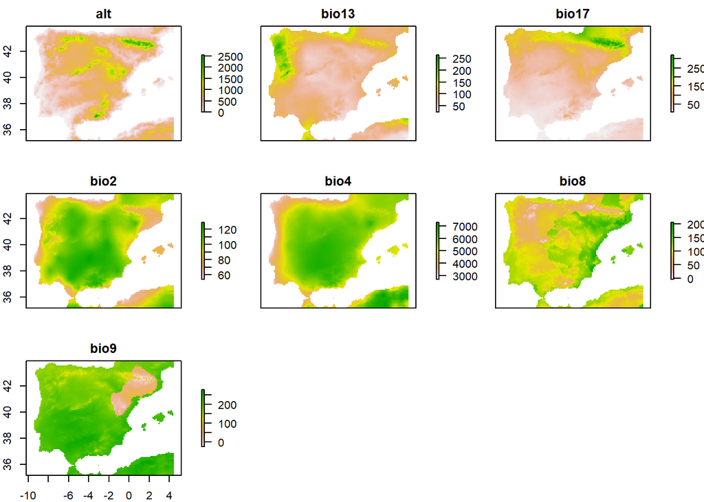

```r
plot(re1)
```

Para un cálculo VIF no tan automatizado procederíamos a transformar los rasters en una tabla, eliminamos valores nulos y calculamos el coef. de correlación de Spearman con cor(, method= c(‘Spearman’)):

```r
var.df<-as.data.frame(VAR_PI_DEF)

var.df<-na.omit(var.df)

var.cor<-cor(var.df, method = c("spearman"))

print(var.cor)
```

```
##               alt        bio1      bio10      bio11       bio12      bio13
## alt    1.00000000 -0.75502461 -0.4887224 -0.8423440 -0.06303005 -0.2269515
## bio1  -0.75502461  1.00000000  0.9024719  0.9420055 -0.30659833 -0.0623988
## bio10 -0.48872242  0.90247191  1.0000000  0.7186664 -0.52367750 -0.3269460
## bio11 -0.84234396  0.94200547  0.7186664  1.0000000 -0.10093471  0.1475302
## bio12 -0.06303005 -0.30659833 -0.5236775 -0.1009347  1.00000000  0.9359943
## bio13 -0.22695151 -0.06239880 -0.3269460  0.1475302  0.93599432  1.0000000
## bio16 -0.22843076 -0.02452198 -0.2818147  0.1768365  0.92763644  0.9858439
## bio17  0.32890779 -0.81020306 -0.8612327 -0.6646861  0.53392446  0.3027969
## bio18  0.28821613 -0.76749053 -0.8346271 -0.6153099  0.52442264  0.3168419
## bio19 -0.23648034  0.05654913 -0.1676826  0.2260868  0.84985987  0.9028778
## bio2   0.34059887 -0.05183400  0.2396740 -0.2631767 -0.49415942 -0.5790520
## bio4   0.44590006 -0.02696887  0.3793624 -0.3207989 -0.57272217 -0.6375054
## bio5  -0.21245389  0.70069407  0.9089873  0.4626668 -0.60594180 -0.4845894
## bio6  -0.85340530  0.89383132  0.6428325  0.9830178  0.01108541  0.2505336
## bio7   0.43821915 -0.02858397  0.3566844 -0.3063122 -0.58435929 -0.6602035
## bio8  -0.43485270  0.39494200  0.3225383  0.3703621 -0.40400145 -0.3250846
## bio9  -0.41590064  0.84015615  0.9359821  0.6708437 -0.44817115 -0.2636119
##             bio16      bio17       bio18       bio19        bio2        bio4
## alt   -0.22843076  0.3289078  0.28821613 -0.23648034  0.34059887  0.44590006
## bio1  -0.02452198 -0.8102031 -0.76749053  0.05654913 -0.05183400 -0.02696887
## bio10 -0.28181473 -0.8612327 -0.83462707 -0.16768263  0.23967405  0.37936244
## bio11  0.17683655 -0.6646861 -0.61530994  0.22608685 -0.26317669 -0.32079891
## bio12  0.92763644  0.5339245  0.52442264  0.84985987 -0.49415942 -0.57272217
## bio13  0.98584390  0.3027969  0.31684190  0.90287778 -0.57905197 -0.63750536
## bio16  1.00000000  0.2357632  0.24122602  0.94798488 -0.55233156 -0.61478993
## bio17  0.23576322  1.0000000  0.98481562  0.08171420 -0.25030635 -0.27747937
## bio18  0.24122602  0.9848156  1.00000000  0.05888235 -0.31567952 -0.31196458
## bio19  0.94798488  0.0817142  0.05888235  1.00000000 -0.43289277 -0.52177134
## bio2  -0.55233156 -0.2503063 -0.31567952 -0.43289277  1.00000000  0.69480206
## bio4  -0.61478993 -0.2774794 -0.31196458 -0.52177134  0.69480206  1.00000000
## bio5  -0.42451527 -0.8164534 -0.82854981 -0.26675391  0.58417602  0.62121300
## bio6   0.28115252 -0.5898333 -0.54160102  0.32368122 -0.38526427 -0.39633159
## bio7  -0.63058763 -0.3083901 -0.36208143 -0.50751854  0.89297635  0.93529254
## bio8  -0.38205328 -0.1803373 -0.10971729 -0.49441240 -0.07061232 -0.03461562
## bio9  -0.20840525 -0.8456842 -0.83967515 -0.04758367  0.28167619  0.35679206
##             bio5        bio6        bio7        bio8        bio9
## alt   -0.2124539 -0.85340530  0.43821915 -0.43485270 -0.41590064
## bio1   0.7006941  0.89383132 -0.02858397  0.39494200  0.84015615
## bio10  0.9089873  0.64283246  0.35668440  0.32253827  0.93598206
## bio11  0.4626668  0.98301778 -0.30631222  0.37036213  0.67084365
## bio12 -0.6059418  0.01108541 -0.58435929 -0.40400145 -0.44817115
## bio13 -0.4845894  0.25053359 -0.66020354 -0.32508457 -0.26361188
## bio16 -0.4245153  0.28115252 -0.63058763 -0.38205328 -0.20840525
## bio17 -0.8164534 -0.58983329 -0.30839010 -0.18033735 -0.84568417
## bio18 -0.8285498 -0.54160102 -0.36208143 -0.10971729 -0.83967515
## bio19 -0.2667539  0.32368122 -0.50751854 -0.49441240 -0.04758367
## bio2   0.5841760 -0.38526427  0.89297635 -0.07061232  0.28167619
## bio4   0.6212130 -0.39633159  0.93529254 -0.03461562  0.35679206
## bio5   1.0000000  0.36189940  0.66910173  0.16647080  0.88300295
## bio6   0.3618994  1.00000000 -0.41006531  0.31020439  0.59903329
## bio7   0.6691017 -0.41006531  1.00000000 -0.08082194  0.37108719
## bio8   0.1664708  0.31020439 -0.08082194  1.00000000  0.15009304
## bio9   0.8830029  0.59903329  0.37108719  0.15009304  1.00000000
```

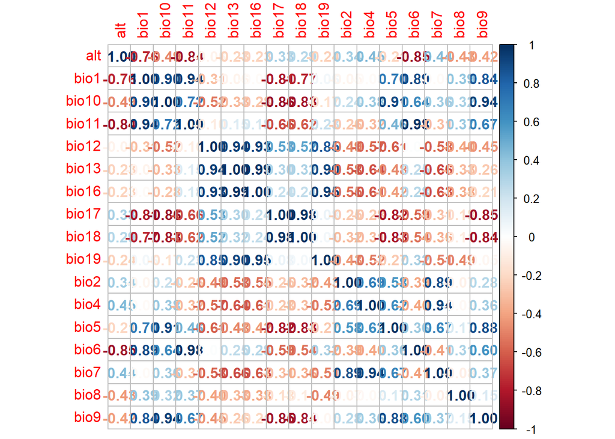

```r
library(corrplot)
corrplot_number<-corrplot(var.cor, method = "number")
```

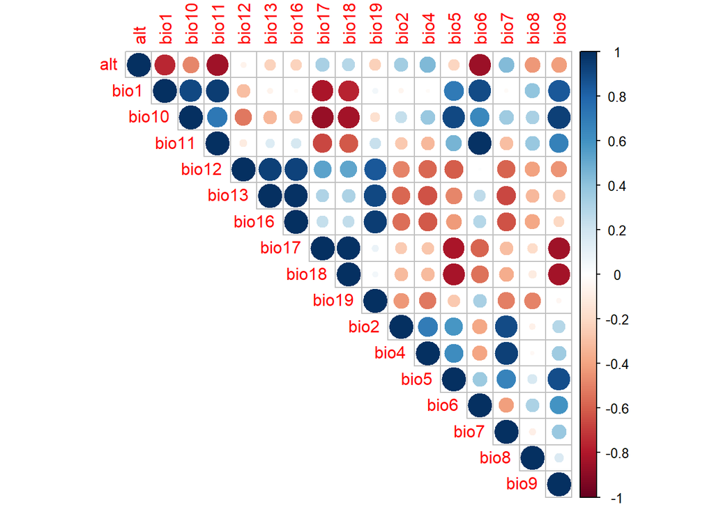

```r
corrplot_circle<-corrplot(var.cor, type = "upper", method = "circle")
```

Acto seguido ransformamos las correlaciones en un dataframe, exploramos la estructura del mismo y exportamos la diagonal superior:

```r
cor.df<-as.data.frame(var.cor)

head(cor.df)
```

```
##               alt       bio1      bio10      bio11       bio12      bio13
## alt    1.00000000 -0.7550246 -0.4887224 -0.8423440 -0.06303005 -0.2269515
## bio1  -0.75502461  1.0000000  0.9024719  0.9420055 -0.30659833 -0.0623988
## bio10 -0.48872242  0.9024719  1.0000000  0.7186664 -0.52367750 -0.3269460
## bio11 -0.84234396  0.9420055  0.7186664  1.0000000 -0.10093471  0.1475302
## bio12 -0.06303005 -0.3065983 -0.5236775 -0.1009347  1.00000000  0.9359943
## bio13 -0.22695151 -0.0623988 -0.3269460  0.1475302  0.93599432  1.0000000
##             bio16      bio17      bio18       bio19       bio2        bio4
## alt   -0.22843076  0.3289078  0.2882161 -0.23648034  0.3405989  0.44590006
## bio1  -0.02452198 -0.8102031 -0.7674905  0.05654913 -0.0518340 -0.02696887
## bio10 -0.28181473 -0.8612327 -0.8346271 -0.16768263  0.2396740  0.37936244
## bio11  0.17683655 -0.6646861 -0.6153099  0.22608685 -0.2631767 -0.32079891
## bio12  0.92763644  0.5339245  0.5244226  0.84985987 -0.4941594 -0.57272217
## bio13  0.98584390  0.3027969  0.3168419  0.90287778 -0.5790520 -0.63750536
##             bio5        bio6        bio7       bio8       bio9
## alt   -0.2124539 -0.85340530  0.43821915 -0.4348527 -0.4159006
## bio1   0.7006941  0.89383132 -0.02858397  0.3949420  0.8401562
## bio10  0.9089873  0.64283246  0.35668440  0.3225383  0.9359821
## bio11  0.4626668  0.98301778 -0.30631222  0.3703621  0.6708437
## bio12 -0.6059418  0.01108541 -0.58435929 -0.4040014 -0.4481712
## bio13 -0.4845894  0.25053359 -0.66020354 -0.3250846 -0.2636119
```

```r
lower<-var.cor
lower[lower.tri(var.cor, diag=TRUE)]<-""
lower.df<-as.data.frame(lower)
lower.df
```

```
##       alt               bio1              bio10              bio11
## alt       -0.755024614665063 -0.488722416692131 -0.842343955571331
## bio1                          0.902471907102344   0.94200546948297
## bio10                                            0.718666398626727
## bio11
## bio12
## bio13
## bio16
## bio17
## bio18
## bio19
## bio2
## bio4
## bio5
## bio6
## bio7
## bio8
## bio9
##                     bio12               bio13               bio16
## alt   -0.0630300495608507  -0.226951513523528  -0.228430755865917
## bio1   -0.306598328812317 -0.0623988024156465 -0.0245219806510336
## bio10   -0.52367750192114  -0.326945980436005  -0.281814730123831
## bio11  -0.100934706915409    0.14753016745712   0.176836545654191
## bio12                       0.935994317651911   0.927636443154284
## bio13                                           0.985843895170654
## bio16
## bio17
## bio18
## bio19
## bio2
## bio4
## bio5
## bio6
## bio7
## bio8
## bio9
##                    bio17              bio18              bio19
## alt    0.328907785425896  0.288216128551793 -0.236480344300398
## bio1  -0.810203061293172  -0.76749052814767 0.0565491327081231
## bio10 -0.861232738551193 -0.834627073018097 -0.167682630121229
```

[output cut: 53 more lines]

```
## bio10   0.935982062727939
## bio11   0.670843654975531
## bio12  -0.448171152906208
## bio13  -0.263611876616241
## bio16  -0.208405253727976
## bio17  -0.845684165455151
## bio18  -0.839675154965829
## bio19 -0.0475836651150607
## bio2    0.281676190457447
## bio4    0.356792064031767
## bio5    0.883002948905909
## bio6    0.599033285684933
## bio7    0.371087192707125
## bio8    0.150093037608033
## bio9
```

```r
write.csv(lower.df, paste(path2work1, "var_correlations.csv"),sep=",")
```

Transformamos la matriz de correlacion en un matriz de distancias y calculamos el dendrograma basado en distancias (less distance = more correlation), con abline() marcamos la línea divisoria que deja bajo ella las variables a escoger:

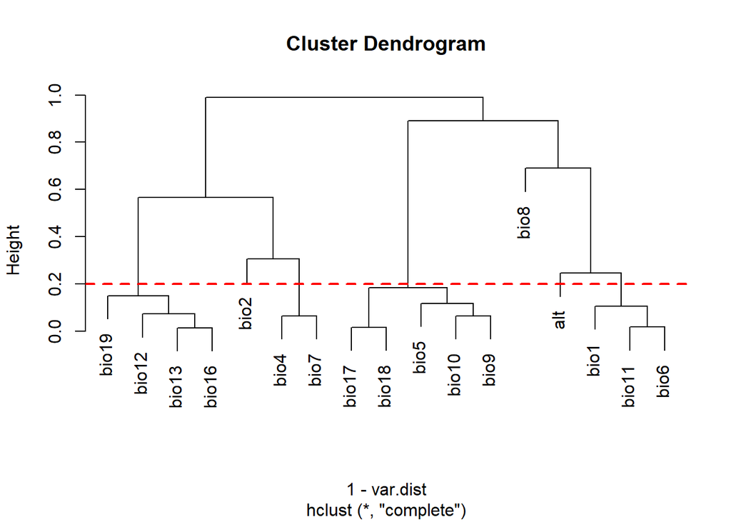

```r
var.dist <- abs(as.dist(cor.df))

var.cluster <- hclust(1-var.dist)

plot(var.cluster)

abline(h=0.2, lty=2, lwd=2, col="red")
```

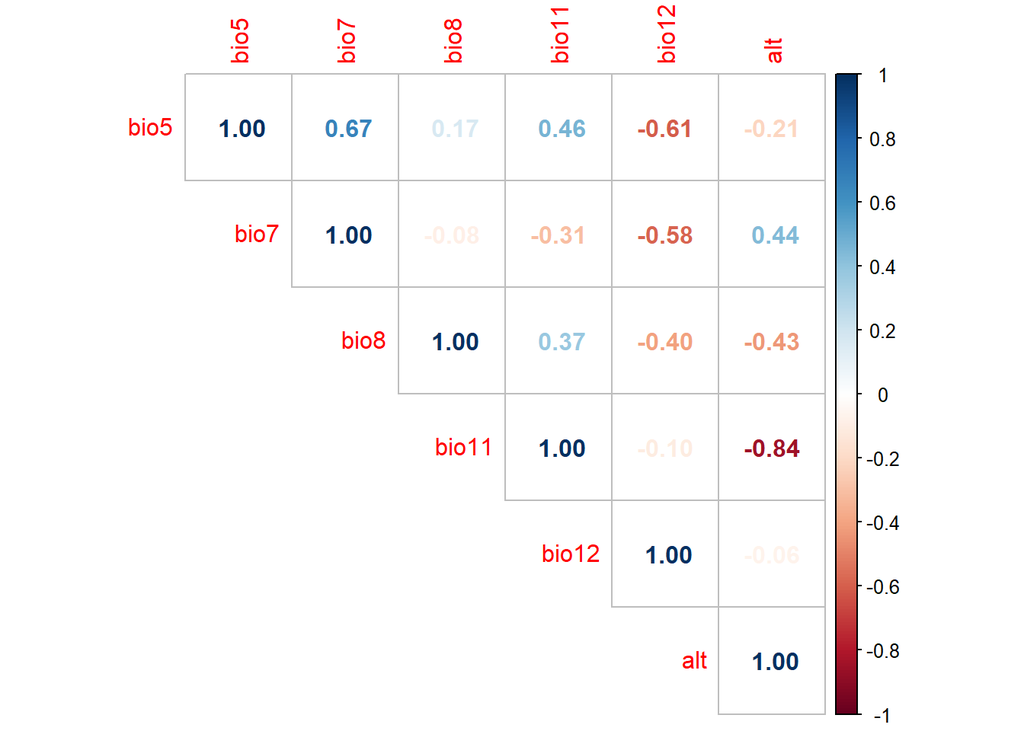

```r
var.selected <- c("bio5", "bio7", "bio8", "bio11", "bio12", "alt")

var.df2<-var.df[ , var.selected]

var.cor<-cor(var.df2, method = c("spearman"))
corrplot_circle<-corrplot(var.cor, type = "upper", method = "number")
```

```r
result.vif<-vif(var.df2)
result.vif
```

```
##   Variables        VIF
## 1      bio5 102.542062
## 2      bio7  90.400194
## 3      bio8   2.025271
## 4     bio11  68.752550
## 5     bio12   2.858705
## 6       alt   4.762706
```

```r
var.df2$bio5<-NULL #VIF = 103.27
result.vif<-vif(var.df2)
result.vif
```

```
##   Variables      VIF
## 1      bio7 2.523857
## 2      bio8 1.902877
## 3     bio11 4.801173
## 4     bio12 2.976636
## 5       alt 4.989703
```

```r
var.df2$bio7<-NULL #VIF = 91.14
result.vif<-vif(var.df2)
result.vif
```

```
##   Variables      VIF
## 1      bio8 1.670384
## 2     bio11 4.364476
## 3     bio12 1.377425
## 4       alt 4.826737
```

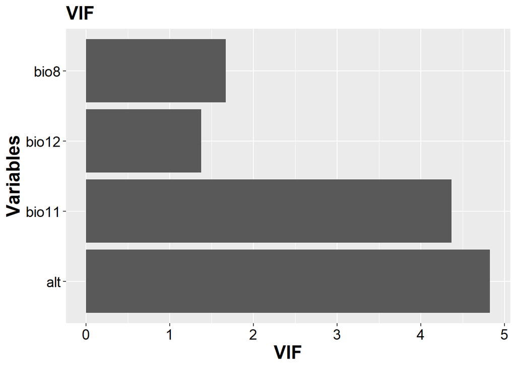

```r
p <- ggplot(data=result.vif, aes(x=Variables, y=VIF), fill = activity) +
  ggtitle("VIF") +
  geom_bar(stat="identity") +
  coord_flip() +
  theme(
    plot.title = element_text(size=18, face="bold"),
    axis.title=element_text(size=18, face="bold"),
    legend.title=element_text(size=14, face="bold"),
    legend.text=element_text(size=12),
    axis.text=element_text(size=14, colour="black"))

p
```

```r
var.selected<-names(var.df2)
var.selected
```

```
## [1] "bio8"  "bio11" "bio12" "alt"
```

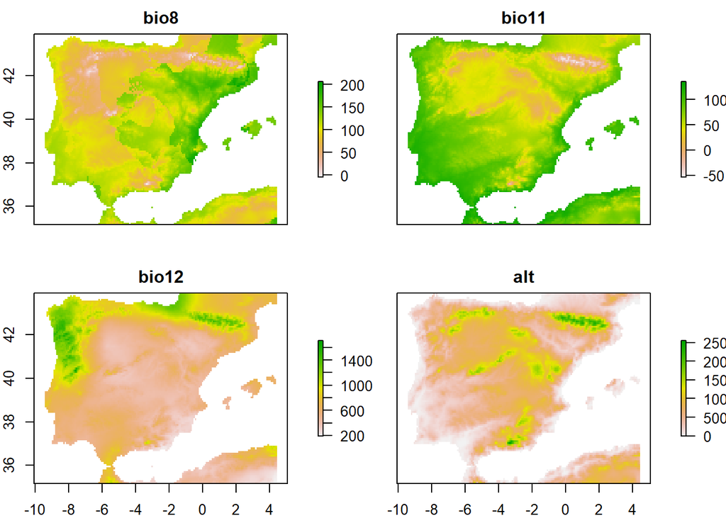

```r
var.def<-brick(VAR_PI[[var.selected]])

plot(var.def)
```

Guardamos las variables seleccionadas para calibrar nuestros ENMs y eliminamos algunos elementos creados en el código para recuperar memoria RAM:

```r
writeRaster(x=var.def, path2work2, names(var.def), bylayer=TRUE, format="ascii", overwrite=TRUE)

rm(var.cor, var.df, var.df2, result.vif, var.cluster, var.dist, var.selected)
gc()
```

```
##           used  (Mb) gc trigger  (Mb) max used  (Mb)
## Ncells 4035265 215.6    6916812 369.4  6916812 369.4
## Vcells 5928854  45.3   12255594  93.6 12255336  93.6
```